# assignment 6 : Clustering

## Group G3_9 (Lab 3)

- Camilla Kuijper (6000118)
- Nikolas Anova (2505401)
- Oscar Kromhof (8170045)

## Step 1: Run the following code

Run this code to get dataset with 2 features and 100 rows. We will work clustering assignment using this dataset.

```r
library(tidyverse)
library(patchwork)

clus_df <- read_csv("https://raw.githubusercontent.com/vankesteren/dav_practicals/master/12_Unsupervised_learning_Clustering/data/clusterdata.csv")
```

[output not shown]

## Step 2: A function for Euclidean distance

```r
#Function for calculating Euclidean distance between 2 vectors
l2_dist <- function(x, y) {
  sqrt(sum((x - y)^2))
}
```

```r
#Try function to calculate  Euclidean distance between record/point no. 1 and 9  from clus_df dataset
l2_dist(clus_df[1,], clus_df[9,])
```

```
## [1] 4.499909
```

## Step 3: K-medians clustering algorithm

This function creates based on algorithm from slide clustering 1 page 26. This is the algorithm steps from kmedians function :

1. Randomly assign examples to K clusters
2. Calculate the centroid (per-feature median) for each cluster
3. Assign each example to the cluster belonging to its closest centroid
4. If the assignments changed, go to step 2, else stop

```r
# Kmedians Function with input X (dataframe), K (number of cluster), and optional input L (number of iteration)
kmedians <- function(X, K, L = 3) {

  # Checking some error before starting the function
  stopifnot(is.data.frame(X))    # X must be data frame
  stopifnot(is.integer(as.integer(K))) # K must be convertible to int

  # Randomly assign X dataset to K temporary clusters
  n_row  <- nrow(X)
  select_vec <- rep(1:K, length.out = n_row)
  X_temp <- X %>% mutate(clusters = sample(select_vec))

  clus_vec <- rep(0, length.out = n_row) # vector for storing cluster number every points


  #Default iteration 3 times, You can change from input function
  for (l in 1:L) {

    # Calculate median every clusters
    med_centroid <- X_temp %>% group_by(clusters) %>% summarize_all(list(med = median))

    # Decide cluster by calculate Euclidean Distance and finding nearest with median centroid
    for (i in 1:n_row) {

      vec <- rep(0, length.out = K) # vector for storing 3 euc distance between a point with K med centroid

      for (j in 1:K) {
        euc_dist <- l2_dist(med_centroid[j,2:3], X_temp[i,1:2])   # Calculate Euclidean Distance
        vec[j] <- euc_dist # Input distance to temporary vector
      }
      clust <- which.min(vec)
      clus_vec[i] <- clust
    }

    #If there are no change in assignment, break iteration
    if (all(X_temp$clusters == clus_vec) == TRUE){
      break
    }

    # Update cluster from result of iteration before
    X_temp <- X %>% mutate(clusters = clus_vec )

  }

  return(clus_vec)
}
```

```r
# Result kmedians function from clus_df dataset with 4 clusters.
clustID <- kmedians(clus_df, 4)
clustID
```

```
##   [1] 2 3 2 4 4 4 2 3 4 2 1 2 1 4 1 1 2 3 4 1 4 1 4 1 2 4 3 4 1 2 2 4 1 2 3 4 1
##  [38] 4 1 1 1 4 2 3 2 2 2 3 2 2 4 4 1 1 1 2 3 2 1 1 2 4 4 1 4 3 1 3 1 2 1 4 4 3
##  [75] 4 4 4 1 1 2 1 3 1 2 2 1 3 2 4 2 3 1 4 2 1 2 1 1 2 2
```

Moreover, We also can change the number iteration. For example iteration 5 times, add input like this : kmedians(clus_df, 4, 5).

## Step 4: Compare to K-means

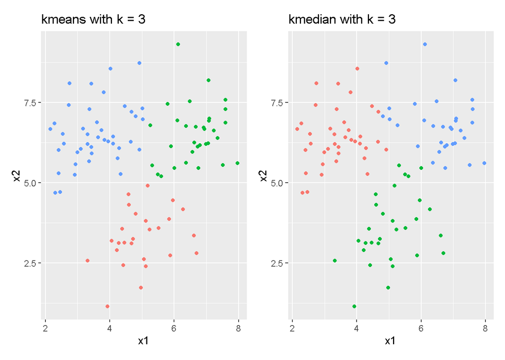

```r
set.seed(3)
k_means <- as_factor(kmeans(clus_df, 3)$cluster)
k_median <- as_factor(kmedians(clus_df, 3))
p1 <- clus_df %>%
  ggplot(aes(x = x1, y = x2, colour = k_means)) +
  geom_point() +
  ggtitle("kmeans with k = 3") +
  theme(legend.position = "n") +
  coord_fixed()

p2 <- clus_df %>%
  ggplot(aes(x = x1, y = x2, colour = k_median)) +
  geom_point() +
  ggtitle("kmedian with k = 3") +
  theme(legend.position = "n") +
  coord_fixed()
p1 + p2
```

We see that the clusterings are very similar only on the boundaries we see that some points are grouped in neighbouring cluster. Note that the labeling (by color) of the clusters is completely arbitrary. For the next visualization we look at k = 4 and see that the two clustering algorithms show very different clusterings.

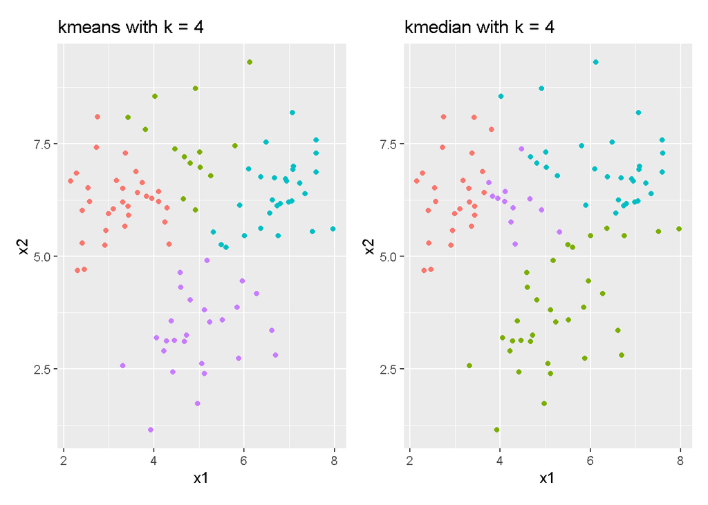

```r
k_means <- as_factor(kmeans(clus_df, 4)$cluster)
k_median <- as_factor(kmedians(clus_df, 4))
p1 <- clus_df %>%
  ggplot(aes(x = x1, y = x2, colour = k_means)) +
  geom_point() +
  ggtitle("kmeans with k = 4") +
  theme(legend.position = "n") +
  coord_fixed()

p2 <- clus_df %>%
  ggplot(aes(x = x1, y = x2, colour = k_median)) +
  geom_point() +
  ggtitle("kmedian with k = 4") +
  theme(legend.position = "n") +
  coord_fixed()
p1 + p2
```